# Risk Factor Analysis

## Outcome Variable

**Outcome Variable:** wast_rec90d

## Predictor Variables

**Intervention Variable:** mage

**Adjustment Set:**

- arm
- meducyrs
- feducyrs
- W_mhtcm
- W_mwtkg
- W_mbmi
- delta_meducyrs
- delta_feducyrs
- delta_W_mhtcm
- delta_W_mwtkg
- delta_W_mbmi

## Stratifying Variables

The analysis was stratified on these variable(s):

- agecat
- studyid
- country

## Data Summary

| agecat | studyid | country | mage | wast_rec90d | n_cell | n |
| --- | --- | --- | --- | --- | --- | --- |
| 0-24 months | CMC-V-BCS-2002 | INDIA | [20-30) | 0 | 98 | 324 |
| 0-24 months | CMC-V-BCS-2002 | INDIA | [20-30) | 1 | 153 | 324 |
| 0-24 months | CMC-V-BCS-2002 | INDIA | <20 | 0 | 8 | 324 |
| 0-24 months | CMC-V-BCS-2002 | INDIA | <20 | 1 | 27 | 324 |
| 0-24 months | CMC-V-BCS-2002 | INDIA | >=30 | 0 | 14 | 324 |
| 0-24 months | CMC-V-BCS-2002 | INDIA | >=30 | 1 | 24 | 324 |
| 0-24 months | COHORTS | GUATEMALA | [20-30) | 0 | 104 | 380 |
| 0-24 months | COHORTS | GUATEMALA | [20-30) | 1 | 79 | 380 |
| 0-24 months | COHORTS | GUATEMALA | <20 | 0 | 24 | 380 |
| 0-24 months | COHORTS | GUATEMALA | <20 | 1 | 28 | 380 |
| 0-24 months | COHORTS | GUATEMALA | >=30 | 0 | 84 | 380 |
| 0-24 months | COHORTS | GUATEMALA | >=30 | 1 | 61 | 380 |
| 0-24 months | COHORTS | INDIA | [20-30) | 0 | 936 | 1940 |
| 0-24 months | COHORTS | INDIA | [20-30) | 1 | 302 | 1940 |
| 0-24 months | COHORTS | INDIA | <20 | 0 | 136 | 1940 |
| 0-24 months | COHORTS | INDIA | <20 | 1 | 34 | 1940 |
| 0-24 months | COHORTS | INDIA | >=30 | 0 | 411 | 1940 |
| 0-24 months | COHORTS | INDIA | >=30 | 1 | 121 | 1940 |
| 0-24 months | COHORTS | PHILIPPINES | [20-30) | 0 | 379 | 1689 |
| 0-24 months | COHORTS | PHILIPPINES | [20-30) | 1 | 575 | 1689 |
| 0-24 months | COHORTS | PHILIPPINES | <20 | 0 | 98 | 1689 |
| 0-24 months | COHORTS | PHILIPPINES | <20 | 1 | 152 | 1689 |
| 0-24 months | COHORTS | PHILIPPINES | >=30 | 0 | 187 | 1689 |
| 0-24 months | COHORTS | PHILIPPINES | >=30 | 1 | 298 | 1689 |
| 0-24 months | EE | PAKISTAN | [20-30) | 0 | 63 | 320 |
| 0-24 months | EE | PAKISTAN | [20-30) | 1 | 61 | 320 |
| 0-24 months | EE | PAKISTAN | <20 | 0 | 0 | 320 |
| 0-24 months | EE | PAKISTAN | <20 | 1 | 1 | 320 |
| 0-24 months | EE | PAKISTAN | >=30 | 0 | 95 | 320 |
| 0-24 months | EE | PAKISTAN | >=30 | 1 | 100 | 320 |

[output cut: 450 more lines]

The following strata were considered:

- agecat: 0-24 months, studyid: CMC-V-BCS-2002, country: INDIA
- agecat: 0-24 months, studyid: COHORTS, country: GUATEMALA
- agecat: 0-24 months, studyid: COHORTS, country: INDIA
- agecat: 0-24 months, studyid: COHORTS, country: PHILIPPINES
- agecat: 0-24 months, studyid: EE, country: PAKISTAN
- agecat: 0-24 months, studyid: GMS-Nepal, country: NEPAL
- agecat: 0-24 months, studyid: Guatemala BSC, country: GUATEMALA
- agecat: 0-24 months, studyid: iLiNS-Zinc, country: BURKINA FASO
- agecat: 0-24 months, studyid: IRC, country: INDIA
- agecat: 0-24 months, studyid: JiVitA-3, country: BANGLADESH
- agecat: 0-24 months, studyid: Keneba, country: GAMBIA
- agecat: 0-24 months, studyid: LCNI-5, country: MALAWI
- agecat: 0-24 months, studyid: MAL-ED, country: BANGLADESH
- agecat: 0-24 months, studyid: MAL-ED, country: BRAZIL
- agecat: 0-24 months, studyid: MAL-ED, country: INDIA
- agecat: 0-24 months, studyid: MAL-ED, country: NEPAL
- agecat: 0-24 months, studyid: MAL-ED, country: PERU
- agecat: 0-24 months, studyid: MAL-ED, country: SOUTH AFRICA
- agecat: 0-24 months, studyid: MAL-ED, country: TANZANIA, UNITED REPUBLIC OF
- agecat: 0-24 months, studyid: NIH-Birth, country: BANGLADESH
- agecat: 0-24 months, studyid: NIH-Crypto, country: BANGLADESH
- agecat: 0-24 months, studyid: PROBIT, country: BELARUS
- agecat: 0-24 months, studyid: PROVIDE, country: BANGLADESH
- agecat: 0-24 months, studyid: SAS-CompFeed, country: INDIA
- agecat: 0-24 months, studyid: SAS-FoodSuppl, country: INDIA
- agecat: 0-24 months, studyid: TanzaniaChild2, country: TANZANIA, UNITED REPUBLIC OF
- agecat: 0-24 months, studyid: ZVITAMBO, country: ZIMBABWE
- agecat: 0-6 months, studyid: CMC-V-BCS-2002, country: INDIA
- agecat: 0-6 months, studyid: COHORTS, country: GUATEMALA
- agecat: 0-6 months, studyid: COHORTS, country: INDIA
- agecat: 0-6 months, studyid: COHORTS, country: PHILIPPINES
- agecat: 0-6 months, studyid: EE, country: PAKISTAN
- agecat: 0-6 months, studyid: GMS-Nepal, country: NEPAL
- agecat: 0-6 months, studyid: Guatemala BSC, country: GUATEMALA
- agecat: 0-6 months, studyid: IRC, country: INDIA
- agecat: 0-6 months, studyid: JiVitA-3, country: BANGLADESH
- agecat: 0-6 months, studyid: Keneba, country: GAMBIA
- agecat: 0-6 months, studyid: LCNI-5, country: MALAWI
- agecat: 0-6 months, studyid: MAL-ED, country: BANGLADESH
- agecat: 0-6 months, studyid: MAL-ED, country: BRAZIL
- agecat: 0-6 months, studyid: MAL-ED, country: INDIA
- agecat: 0-6 months, studyid: MAL-ED, country: NEPAL
- agecat: 0-6 months, studyid: MAL-ED, country: PERU
- agecat: 0-6 months, studyid: MAL-ED, country: SOUTH AFRICA
- agecat: 0-6 months, studyid: MAL-ED, country: TANZANIA, UNITED REPUBLIC OF
- agecat: 0-6 months, studyid: NIH-Birth, country: BANGLADESH
- agecat: 0-6 months, studyid: NIH-Crypto, country: BANGLADESH
- agecat: 0-6 months, studyid: PROBIT, country: BELARUS
- agecat: 0-6 months, studyid: PROVIDE, country: BANGLADESH
- agecat: 0-6 months, studyid: SAS-CompFeed, country: INDIA
- agecat: 0-6 months, studyid: SAS-FoodSuppl, country: INDIA
- agecat: 0-6 months, studyid: TanzaniaChild2, country: TANZANIA, UNITED REPUBLIC OF
- agecat: 0-6 months, studyid: ZVITAMBO, country: ZIMBABWE
- agecat: 6-24 months, studyid: CMC-V-BCS-2002, country: INDIA
- agecat: 6-24 months, studyid: COHORTS, country: GUATEMALA
- agecat: 6-24 months, studyid: COHORTS, country: INDIA
- agecat: 6-24 months, studyid: COHORTS, country: PHILIPPINES
- agecat: 6-24 months, studyid: EE, country: PAKISTAN
- agecat: 6-24 months, studyid: GMS-Nepal, country: NEPAL
- agecat: 6-24 months, studyid: Guatemala BSC, country: GUATEMALA
- agecat: 6-24 months, studyid: iLiNS-Zinc, country: BURKINA FASO
- agecat: 6-24 months, studyid: IRC, country: INDIA
- agecat: 6-24 months, studyid: JiVitA-3, country: BANGLADESH
- agecat: 6-24 months, studyid: Keneba, country: GAMBIA
- agecat: 6-24 months, studyid: LCNI-5, country: MALAWI
- agecat: 6-24 months, studyid: MAL-ED, country: BANGLADESH
- agecat: 6-24 months, studyid: MAL-ED, country: BRAZIL
- agecat: 6-24 months, studyid: MAL-ED, country: INDIA
- agecat: 6-24 months, studyid: MAL-ED, country: NEPAL
- agecat: 6-24 months, studyid: MAL-ED, country: PERU
- agecat: 6-24 months, studyid: MAL-ED, country: SOUTH AFRICA
- agecat: 6-24 months, studyid: MAL-ED, country: TANZANIA, UNITED REPUBLIC OF
- agecat: 6-24 months, studyid: NIH-Birth, country: BANGLADESH
- agecat: 6-24 months, studyid: NIH-Crypto, country: BANGLADESH
- agecat: 6-24 months, studyid: PROBIT, country: BELARUS
- agecat: 6-24 months, studyid: PROVIDE, country: BANGLADESH
- agecat: 6-24 months, studyid: SAS-CompFeed, country: INDIA
- agecat: 6-24 months, studyid: SAS-FoodSuppl, country: INDIA
- agecat: 6-24 months, studyid: TanzaniaChild2, country: TANZANIA, UNITED REPUBLIC OF
- agecat: 6-24 months, studyid: ZVITAMBO, country: ZIMBABWE

### Dropped Strata

Some strata were dropped due to rare outcomes:

- agecat: 0-24 months, studyid: EE, country: PAKISTAN
- agecat: 0-24 months, studyid: Guatemala BSC, country: GUATEMALA
- agecat: 0-24 months, studyid: iLiNS-Zinc, country: BURKINA FASO
- agecat: 0-24 months, studyid: LCNI-5, country: MALAWI
- agecat: 0-24 months, studyid: MAL-ED, country: BRAZIL
- agecat: 0-24 months, studyid: MAL-ED, country: INDIA
- agecat: 0-24 months, studyid: MAL-ED, country: NEPAL
- agecat: 0-24 months, studyid: MAL-ED, country: PERU
- agecat: 0-24 months, studyid: MAL-ED, country: SOUTH AFRICA
- agecat: 0-24 months, studyid: MAL-ED, country: TANZANIA, UNITED REPUBLIC OF
- agecat: 0-24 months, studyid: SAS-FoodSuppl, country: INDIA
- agecat: 0-6 months, studyid: CMC-V-BCS-2002, country: INDIA
- agecat: 0-6 months, studyid: EE, country: PAKISTAN
- agecat: 0-6 months, studyid: Guatemala BSC, country: GUATEMALA
- agecat: 0-6 months, studyid: LCNI-5, country: MALAWI
- agecat: 0-6 months, studyid: MAL-ED, country: BANGLADESH
- agecat: 0-6 months, studyid: MAL-ED, country: BRAZIL
- agecat: 0-6 months, studyid: MAL-ED, country: INDIA
- agecat: 0-6 months, studyid: MAL-ED, country: NEPAL
- agecat: 0-6 months, studyid: MAL-ED, country: PERU
- agecat: 0-6 months, studyid: MAL-ED, country: SOUTH AFRICA
- agecat: 0-6 months, studyid: MAL-ED, country: TANZANIA, UNITED REPUBLIC OF
- agecat: 0-6 months, studyid: NIH-Crypto, country: BANGLADESH
- agecat: 0-6 months, studyid: PROVIDE, country: BANGLADESH
- agecat: 0-6 months, studyid: SAS-FoodSuppl, country: INDIA
- agecat: 6-24 months, studyid: CMC-V-BCS-2002, country: INDIA
- agecat: 6-24 months, studyid: COHORTS, country: GUATEMALA
- agecat: 6-24 months, studyid: COHORTS, country: INDIA
- agecat: 6-24 months, studyid: EE, country: PAKISTAN
- agecat: 6-24 months, studyid: Guatemala BSC, country: GUATEMALA
- agecat: 6-24 months, studyid: iLiNS-Zinc, country: BURKINA FASO
- agecat: 6-24 months, studyid: IRC, country: INDIA
- agecat: 6-24 months, studyid: JiVitA-3, country: BANGLADESH
- agecat: 6-24 months, studyid: LCNI-5, country: MALAWI
- agecat: 6-24 months, studyid: MAL-ED, country: BRAZIL
- agecat: 6-24 months, studyid: MAL-ED, country: INDIA
- agecat: 6-24 months, studyid: MAL-ED, country: NEPAL
- agecat: 6-24 months, studyid: MAL-ED, country: PERU
- agecat: 6-24 months, studyid: MAL-ED, country: SOUTH AFRICA
- agecat: 6-24 months, studyid: MAL-ED, country: TANZANIA, UNITED REPUBLIC OF
- agecat: 6-24 months, studyid: NIH-Birth, country: BANGLADESH
- agecat: 6-24 months, studyid: NIH-Crypto, country: BANGLADESH
- agecat: 6-24 months, studyid: PROBIT, country: BELARUS
- agecat: 6-24 months, studyid: SAS-FoodSuppl, country: INDIA

## Methods Detail

We’re interested in the causal parameters $E[Y_a]$ for all values of $a \in \mathcal{A}$. These parameters represent the mean outcome if, possibly contrary to fact, we intervened to set all units to have $A=a$. Under the randomization and positivity assumptions, these are identified by the statistical parameters $\psi_a=E_W[E_{Y|A,W}(Y|A=a,W)]$. In addition, we’re interested in the mean of $Y$, $E[Y]$ under no intervention (the observed mean). We will estimate these parameters by using SuperLearner to fit the relevant likelihood factors – $E_{Y|A,W}(Y|A=a,W)$ and $p(A=a|W)$, and then updating our likelihood fit using a joint TMLE.

For unadjusted analyses ($W=\{\}$), initial likelihoods were estimated using Lrnr_glm to estimate the simple $E(Y|A)$ and Lrnr_mean to estimate $p(A)$. For adjusted analyses, a small library containing Lrnr_glmnet, Lrnr_xgboost, and Lrnr_mean was used.

Having estimated these parameters, we will then use the delta method to estimate relative risks and attributable risks relative to a prespecified baseline level of $A$.

# Results Detail

## Results Plots

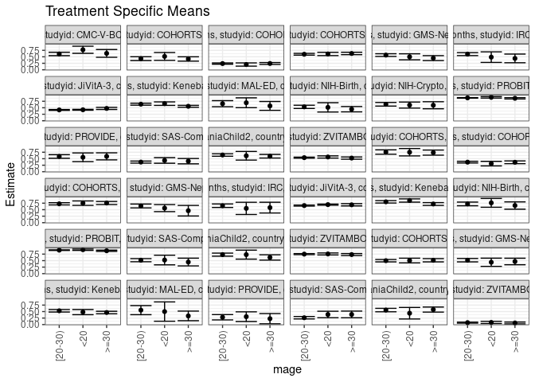

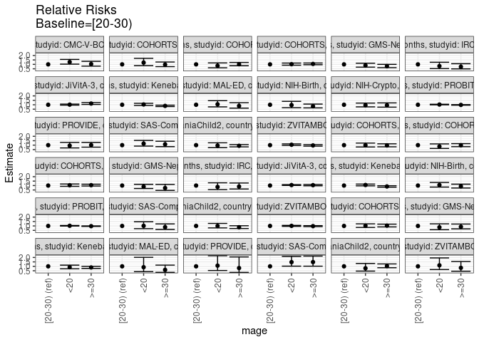

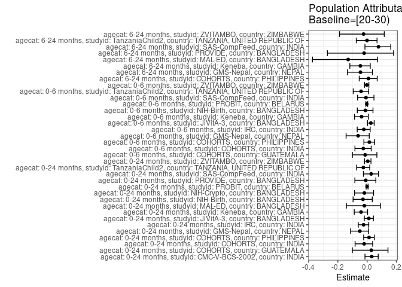

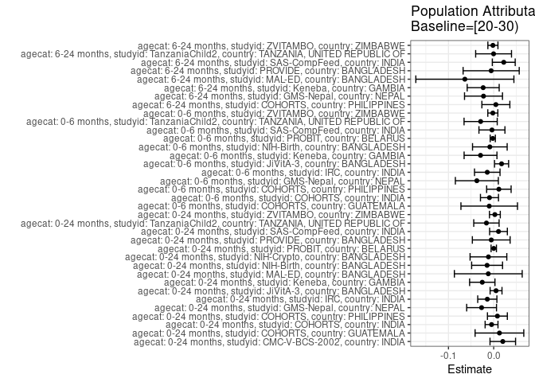

## Results Table

### Parameter: TSM

| agecat | studyid | country | intervention_level | baseline_level | estimate | ci_lower | ci_upper |
| --- | --- | --- | --- | --- | --- | --- | --- |
| 0-24 months | CMC-V-BCS-2002 | INDIA | [20-30) | NA | 0.6095618 | 0.5440036 | 0.6751199 |
| 0-24 months | CMC-V-BCS-2002 | INDIA | <20 | NA | 0.7714286 | 0.6337889 | 0.9090682 |
| 0-24 months | CMC-V-BCS-2002 | INDIA | >=30 | NA | 0.6315789 | 0.4824082 | 0.7807497 |
| 0-24 months | COHORTS | GUATEMALA | [20-30) | NA | 0.4294307 | 0.3562965 | 0.5025648 |
| 0-24 months | COHORTS | GUATEMALA | <20 | NA | 0.5150781 | 0.3641829 | 0.6659734 |
| 0-24 months | COHORTS | GUATEMALA | >=30 | NA | 0.4169785 | 0.3332573 | 0.5006998 |
| 0-24 months | COHORTS | INDIA | [20-30) | NA | 0.2403202 | 0.2159476 | 0.2646928 |
| 0-24 months | COHORTS | INDIA | <20 | NA | 0.2033618 | 0.1417250 | 0.2649986 |
| 0-24 months | COHORTS | INDIA | >=30 | NA | 0.2435215 | 0.2065181 | 0.2805250 |
| 0-24 months | COHORTS | PHILIPPINES | [20-30) | NA | 0.5987091 | 0.5647036 | 0.6327146 |
| 0-24 months | COHORTS | PHILIPPINES | <20 | NA | 0.6107418 | 0.5470037 | 0.6744799 |
| 0-24 months | COHORTS | PHILIPPINES | >=30 | NA | 0.6287816 | 0.5826232 | 0.6749401 |
| 0-24 months | GMS-Nepal | NEPAL | [20-30) | NA | 0.5664420 | 0.5151130 | 0.6177710 |
| 0-24 months | GMS-Nepal | NEPAL | <20 | NA | 0.4992479 | 0.3830591 | 0.6154366 |
| 0-24 months | GMS-Nepal | NEPAL | >=30 | NA | 0.4501825 | 0.3551816 | 0.5451834 |
| 0-24 months | IRC | INDIA | [20-30) | NA | 0.6040079 | 0.5469527 | 0.6610631 |
| 0-24 months | IRC | INDIA | <20 | NA | 0.4871962 | 0.2837427 | 0.6906497 |
| 0-24 months | IRC | INDIA | >=30 | NA | 0.4384235 | 0.2715381 | 0.6053089 |
| 0-24 months | JiVitA-3 | BANGLADESH | [20-30) | NA | 0.4170017 | 0.3996685 | 0.4343348 |
| 0-24 months | JiVitA-3 | BANGLADESH | <20 | NA | 0.4224163 | 0.4049360 | 0.4398967 |
| 0-24 months | JiVitA-3 | BANGLADESH | >=30 | NA | 0.4749605 | 0.4349299 | 0.5149912 |
| 0-24 months | Keneba | GAMBIA | [20-30) | NA | 0.6379067 | 0.5998744 | 0.6759391 |
| 0-24 months | Keneba | GAMBIA | <20 | NA | 0.6586361 | 0.5911899 | 0.7260823 |
| 0-24 months | Keneba | GAMBIA | >=30 | NA | 0.5562895 | 0.5195093 | 0.5930697 |
| 0-24 months | MAL-ED | BANGLADESH | [20-30) | NA | 0.6571429 | 0.5406898 | 0.7735959 |
| 0-24 months | MAL-ED | BANGLADESH | <20 | NA | 0.6923077 | 0.5029558 | 0.8816596 |
| 0-24 months | MAL-ED | BANGLADESH | >=30 | NA | 0.5714286 | 0.4018241 | 0.7410330 |
| 0-24 months | NIH-Birth | BANGLADESH | [20-30) | NA | 0.5348979 | 0.4731723 | 0.5966234 |
| 0-24 months | NIH-Birth | BANGLADESH | <20 | NA | 0.5150200 | 0.3360886 | 0.6939515 |
| 0-24 months | NIH-Birth | BANGLADESH | >=30 | NA | 0.4454619 | 0.3423990 | 0.5485247 |

[output cut: 78 more lines]

### Parameter: E(Y)

| agecat | studyid | country | intervention_level | baseline_level | estimate | ci_lower | ci_upper |
| --- | --- | --- | --- | --- | --- | --- | --- |
| 0-24 months | CMC-V-BCS-2002 | INDIA | NA | NA | 0.6296296 | 0.5734927 | 0.6857666 |
| 0-24 months | COHORTS | GUATEMALA | NA | NA | 0.4421053 | 0.3904403 | 0.4937702 |
| 0-24 months | COHORTS | INDIA | NA | NA | 0.2355670 | 0.2165976 | 0.2545364 |
| 0-24 months | COHORTS | PHILIPPINES | NA | NA | 0.6068680 | 0.5823645 | 0.6313715 |
| 0-24 months | GMS-Nepal | NEPAL | NA | NA | 0.5396579 | 0.4973524 | 0.5819633 |
| 0-24 months | IRC | INDIA | NA | NA | 0.5898734 | 0.5376978 | 0.6420491 |
| 0-24 months | JiVitA-3 | BANGLADESH | NA | NA | 0.4221929 | 0.4110723 | 0.4333134 |
| 0-24 months | Keneba | GAMBIA | NA | NA | 0.6126374 | 0.5884768 | 0.6367979 |
| 0-24 months | MAL-ED | BANGLADESH | NA | NA | 0.6451613 | 0.5593015 | 0.7310211 |
| 0-24 months | NIH-Birth | BANGLADESH | NA | NA | 0.5202864 | 0.4695109 | 0.5710618 |
| 0-24 months | NIH-Crypto | BANGLADESH | NA | NA | 0.6225806 | 0.5684562 | 0.6767051 |
| 0-24 months | PROBIT | BELARUS | NA | NA | 0.8806715 | 0.8711794 | 0.8901636 |
| 0-24 months | PROVIDE | BANGLADESH | NA | NA | 0.5811688 | 0.5245443 | 0.6377934 |
| 0-24 months | SAS-CompFeed | INDIA | NA | NA | 0.3808354 | 0.3457640 | 0.4159068 |
| 0-24 months | TanzaniaChild2 | TANZANIA, UNITED REPUBLIC OF | NA | NA | 0.6267606 | 0.5890263 | 0.6644948 |
| 0-24 months | ZVITAMBO | ZIMBABWE | NA | NA | 0.5434360 | 0.5270156 | 0.5598565 |
| 0-6 months | COHORTS | GUATEMALA | NA | NA | 0.7476636 | 0.6894668 | 0.8058603 |
| 0-6 months | COHORTS | INDIA | NA | NA | 0.3581505 | 0.3318331 | 0.3844678 |
| 0-6 months | COHORTS | PHILIPPINES | NA | NA | 0.7367021 | 0.7051294 | 0.7682749 |
| 0-6 months | GMS-Nepal | NEPAL | NA | NA | 0.6045627 | 0.5449300 | 0.6641955 |
| 0-6 months | IRC | INDIA | NA | NA | 0.6375000 | 0.5751450 | 0.6998550 |
| 0-6 months | JiVitA-3 | BANGLADESH | NA | NA | 0.6752588 | 0.6619177 | 0.6885999 |
| 0-6 months | Keneba | GAMBIA | NA | NA | 0.7728532 | 0.7426787 | 0.8030276 |
| 0-6 months | NIH-Birth | BANGLADESH | NA | NA | 0.7130045 | 0.6535890 | 0.7724200 |
| 0-6 months | PROBIT | BELARUS | NA | NA | 0.9008671 | 0.8918443 | 0.9098900 |
| 0-6 months | SAS-CompFeed | INDIA | NA | NA | 0.5131965 | 0.4596632 | 0.5667297 |
| 0-6 months | TanzaniaChild2 | TANZANIA, UNITED REPUBLIC OF | NA | NA | 0.7020649 | 0.6526590 | 0.7514708 |
| 0-6 months | ZVITAMBO | ZIMBABWE | NA | NA | 0.7485054 | 0.7315407 | 0.7654701 |
| 6-24 months | COHORTS | PHILIPPINES | NA | NA | 0.5026681 | 0.4688378 | 0.5364984 |
| 6-24 months | GMS-Nepal | NEPAL | NA | NA | 0.4947368 | 0.4401559 | 0.5493178 |
| 6-24 months | Keneba | GAMBIA | NA | NA | 0.5072860 | 0.4757518 | 0.5388202 |
| 6-24 months | MAL-ED | BANGLADESH | NA | NA | 0.4918033 | 0.3610932 | 0.6225134 |
| 6-24 months | PROVIDE | BANGLADESH | NA | NA | 0.2764228 | 0.1950773 | 0.3577682 |
| 6-24 months | SAS-CompFeed | INDIA | NA | NA | 0.2854123 | 0.2436284 | 0.3271961 |
| 6-24 months | TanzaniaChild2 | TANZANIA, UNITED REPUBLIC OF | NA | NA | 0.5579515 | 0.5056058 | 0.6102972 |
| 6-24 months | ZVITAMBO | ZIMBABWE | NA | NA | 0.0731261 | 0.0577817 | 0.0884705 |

### Parameter: RR

| agecat | studyid | country | intervention_level | baseline_level | estimate | ci_lower | ci_upper |
| --- | --- | --- | --- | --- | --- | --- | --- |
| 0-24 months | CMC-V-BCS-2002 | INDIA | [20-30) | [20-30) | 1.0000000 | 1.0000000 | 1.0000000 |
| 0-24 months | CMC-V-BCS-2002 | INDIA | <20 | [20-30) | 1.2655462 | 1.0275196 | 1.5587122 |
| 0-24 months | CMC-V-BCS-2002 | INDIA | >=30 | [20-30) | 1.0361197 | 0.7992780 | 1.3431423 |
| 0-24 months | COHORTS | GUATEMALA | [20-30) | [20-30) | 1.0000000 | 1.0000000 | 1.0000000 |
| 0-24 months | COHORTS | GUATEMALA | <20 | [20-30) | 1.1994442 | 0.8546165 | 1.6834058 |
| 0-24 months | COHORTS | GUATEMALA | >=30 | [20-30) | 0.9710032 | 0.7457676 | 1.2642641 |
| 0-24 months | COHORTS | INDIA | [20-30) | [20-30) | 1.0000000 | 1.0000000 | 1.0000000 |
| 0-24 months | COHORTS | INDIA | <20 | [20-30) | 0.8462120 | 0.6146018 | 1.1651036 |
| 0-24 months | COHORTS | INDIA | >=30 | [20-30) | 1.0133212 | 0.8443898 | 1.2160495 |
| 0-24 months | COHORTS | PHILIPPINES | [20-30) | [20-30) | 1.0000000 | 1.0000000 | 1.0000000 |
| 0-24 months | COHORTS | PHILIPPINES | <20 | [20-30) | 1.0200977 | 0.9058460 | 1.1487595 |
| 0-24 months | COHORTS | PHILIPPINES | >=30 | [20-30) | 1.0502289 | 0.9572597 | 1.1522273 |
| 0-24 months | GMS-Nepal | NEPAL | [20-30) | [20-30) | 1.0000000 | 1.0000000 | 1.0000000 |
| 0-24 months | GMS-Nepal | NEPAL | <20 | [20-30) | 0.8813750 | 0.6864190 | 1.1317022 |
| 0-24 months | GMS-Nepal | NEPAL | >=30 | [20-30) | 0.7947548 | 0.6315411 | 1.0001489 |
| 0-24 months | IRC | INDIA | [20-30) | [20-30) | 1.0000000 | 1.0000000 | 1.0000000 |
| 0-24 months | IRC | INDIA | <20 | [20-30) | 0.8066057 | 0.5261103 | 1.2366471 |
| 0-24 months | IRC | INDIA | >=30 | [20-30) | 0.7258573 | 0.4899728 | 1.0753020 |
| 0-24 months | JiVitA-3 | BANGLADESH | [20-30) | [20-30) | 1.0000000 | 1.0000000 | 1.0000000 |
| 0-24 months | JiVitA-3 | BANGLADESH | <20 | [20-30) | 1.0129848 | 0.9552932 | 1.0741605 |
| 0-24 months | JiVitA-3 | BANGLADESH | >=30 | [20-30) | 1.1389895 | 1.0368474 | 1.2511940 |
| 0-24 months | Keneba | GAMBIA | [20-30) | [20-30) | 1.0000000 | 1.0000000 | 1.0000000 |
| 0-24 months | Keneba | GAMBIA | <20 | [20-30) | 1.0324959 | 0.9172113 | 1.1622708 |
| 0-24 months | Keneba | GAMBIA | >=30 | [20-30) | 0.8720547 | 0.7980042 | 0.9529766 |
| 0-24 months | MAL-ED | BANGLADESH | [20-30) | [20-30) | 1.0000000 | 1.0000000 | 1.0000000 |
| 0-24 months | MAL-ED | BANGLADESH | <20 | [20-30) | 1.0535117 | 0.7605022 | 1.4594131 |
| 0-24 months | MAL-ED | BANGLADESH | >=30 | [20-30) | 0.8695652 | 0.6151686 | 1.2291649 |
| 0-24 months | NIH-Birth | BANGLADESH | [20-30) | [20-30) | 1.0000000 | 1.0000000 | 1.0000000 |
| 0-24 months | NIH-Birth | BANGLADESH | <20 | [20-30) | 0.9628381 | 0.6680721 | 1.3876603 |
| 0-24 months | NIH-Birth | BANGLADESH | >=30 | [20-30) | 0.8327980 | 0.6435310 | 1.0777296 |

[output cut: 78 more lines]

### Parameter: PAR

| agecat | studyid | country | intervention_level | baseline_level | estimate | ci_lower | ci_upper |
| --- | --- | --- | --- | --- | --- | --- | --- |
| 0-24 months | CMC-V-BCS-2002 | INDIA | [20-30) | NA | 0.0200679 | -0.0081753 | 0.0483111 |
| 0-24 months | COHORTS | GUATEMALA | [20-30) | NA | 0.0126746 | -0.0411496 | 0.0664988 |
| 0-24 months | COHORTS | INDIA | [20-30) | NA | -0.0047532 | -0.0189602 | 0.0094538 |
| 0-24 months | COHORTS | PHILIPPINES | [20-30) | NA | 0.0081588 | -0.0138341 | 0.0301517 |
| 0-24 months | GMS-Nepal | NEPAL | [20-30) | NA | -0.0267842 | -0.0597441 | 0.0061757 |
| 0-24 months | IRC | INDIA | [20-30) | NA | -0.0141344 | -0.0353235 | 0.0070546 |
| 0-24 months | JiVitA-3 | BANGLADESH | [20-30) | NA | 0.0051912 | -0.0079478 | 0.0183302 |
| 0-24 months | Keneba | GAMBIA | [20-30) | NA | -0.0252694 | -0.0533082 | 0.0027695 |
| 0-24 months | MAL-ED | BANGLADESH | [20-30) | NA | -0.0119816 | -0.0869654 | 0.0630023 |
| 0-24 months | NIH-Birth | BANGLADESH | [20-30) | NA | -0.0146115 | -0.0487618 | 0.0195389 |
| 0-24 months | NIH-Crypto | BANGLADESH | [20-30) | NA | -0.0116380 | -0.0522366 | 0.0289607 |
| 0-24 months | PROBIT | BELARUS | [20-30) | NA | 0.0001107 | -0.0058170 | 0.0060385 |
| 0-24 months | PROVIDE | BANGLADESH | [20-30) | NA | -0.0054369 | -0.0471723 | 0.0362984 |
| 0-24 months | SAS-CompFeed | INDIA | [20-30) | NA | 0.0105757 | -0.0090342 | 0.0301856 |
| 0-24 months | TanzaniaChild2 | TANZANIA, UNITED REPUBLIC OF | [20-30) | NA | -0.0160983 | -0.0441119 | 0.0119154 |
| 0-24 months | ZVITAMBO | ZIMBABWE | [20-30) | NA | 0.0025851 | -0.0093790 | 0.0145492 |
| 0-6 months | COHORTS | GUATEMALA | [20-30) | NA | -0.0099122 | -0.0724377 | 0.0526132 |
| 0-6 months | COHORTS | INDIA | [20-30) | NA | -0.0093459 | -0.0292662 | 0.0105745 |
| 0-6 months | COHORTS | PHILIPPINES | [20-30) | NA | 0.0114302 | -0.0156245 | 0.0384848 |
| 0-6 months | GMS-Nepal | NEPAL | [20-30) | NA | -0.0372546 | -0.0847538 | 0.0102445 |
| 0-6 months | IRC | INDIA | [20-30) | NA | -0.0142413 | -0.0424320 | 0.0139495 |
| 0-6 months | JiVitA-3 | BANGLADESH | [20-30) | NA | 0.0173913 | 0.0018394 | 0.0329433 |
| 0-6 months | Keneba | GAMBIA | [20-30) | NA | -0.0291179 | -0.0654204 | 0.0071846 |
| 0-6 months | NIH-Birth | BANGLADESH | [20-30) | NA | -0.0085145 | -0.0467921 | 0.0297631 |
| 0-6 months | PROBIT | BELARUS | [20-30) | NA | -0.0020612 | -0.0077805 | 0.0036581 |
| 0-6 months | SAS-CompFeed | INDIA | [20-30) | NA | -0.0038926 | -0.0326263 | 0.0248410 |
| 0-6 months | TanzaniaChild2 | TANZANIA, UNITED REPUBLIC OF | [20-30) | NA | -0.0288768 | -0.0655418 | 0.0077881 |
| 0-6 months | ZVITAMBO | ZIMBABWE | [20-30) | NA | -0.0019533 | -0.0130440 | 0.0091373 |
| 6-24 months | COHORTS | PHILIPPINES | [20-30) | NA | 0.0047862 | -0.0261359 | 0.0357083 |
| 6-24 months | GMS-Nepal | NEPAL | [20-30) | NA | -0.0225432 | -0.0645099 | 0.0194236 |
| 6-24 months | Keneba | GAMBIA | [20-30) | NA | -0.0232729 | -0.0586488 | 0.0121030 |
| 6-24 months | MAL-ED | BANGLADESH | [20-30) | NA | -0.0637523 | -0.1721469 | 0.0446423 |
| 6-24 months | PROVIDE | BANGLADESH | [20-30) | NA | -0.0056285 | -0.0676577 | 0.0564006 |
| 6-24 months | SAS-CompFeed | INDIA | [20-30) | NA | 0.0222357 | -0.0030564 | 0.0475279 |
| 6-24 months | TanzaniaChild2 | TANZANIA, UNITED REPUBLIC OF | [20-30) | NA | -0.0002696 | -0.0398841 | 0.0393449 |
| 6-24 months | ZVITAMBO | ZIMBABWE | [20-30) | NA | -0.0017748 | -0.0129152 | 0.0093655 |

### Parameter: PAF

| agecat | studyid | country | intervention_level | baseline_level | estimate | ci_lower | ci_upper |
| --- | --- | --- | --- | --- | --- | --- | --- |
| 0-24 months | CMC-V-BCS-2002 | INDIA | [20-30) | NA | 0.0318725 | -0.0144597 | 0.0760887 |
| 0-24 months | COHORTS | GUATEMALA | [20-30) | NA | 0.0286687 | -0.1009388 | 0.1430183 |
| 0-24 months | COHORTS | INDIA | [20-30) | NA | -0.0201776 | -0.0822253 | 0.0383127 |
| 0-24 months | COHORTS | PHILIPPINES | [20-30) | NA | 0.0134442 | -0.0235116 | 0.0490656 |
| 0-24 months | GMS-Nepal | NEPAL | [20-30) | NA | -0.0496318 | -0.1130059 | 0.0101338 |
| 0-24 months | IRC | INDIA | [20-30) | NA | -0.0239618 | -0.0605020 | 0.0113194 |
| 0-24 months | JiVitA-3 | BANGLADESH | [20-30) | NA | 0.0122958 | -0.0193270 | 0.0429376 |
| 0-24 months | Keneba | GAMBIA | [20-30) | NA | -0.0412468 | -0.0879692 | 0.0034691 |
| 0-24 months | MAL-ED | BANGLADESH | [20-30) | NA | -0.0185714 | -0.1415944 | 0.0911941 |
| 0-24 months | NIH-Birth | BANGLADESH | [20-30) | NA | -0.0280835 | -0.0958674 | 0.0355076 |
| 0-24 months | NIH-Crypto | BANGLADESH | [20-30) | NA | -0.0186931 | -0.0859672 | 0.0444135 |
| 0-24 months | PROBIT | BELARUS | [20-30) | NA | 0.0001257 | -0.0066279 | 0.0068340 |
| 0-24 months | PROVIDE | BANGLADESH | [20-30) | NA | -0.0093552 | -0.0838200 | 0.0599935 |
| 0-24 months | SAS-CompFeed | INDIA | [20-30) | NA | 0.0277697 | -0.0251452 | 0.0779533 |
| 0-24 months | TanzaniaChild2 | TANZANIA, UNITED REPUBLIC OF | [20-30) | NA | -0.0256849 | -0.0714356 | 0.0181123 |
| 0-24 months | ZVITAMBO | ZIMBABWE | [20-30) | NA | 0.0047569 | -0.0175046 | 0.0265314 |
| 0-6 months | COHORTS | GUATEMALA | [20-30) | NA | -0.0132576 | -0.1004856 | 0.0670564 |
| 0-6 months | COHORTS | INDIA | [20-30) | NA | -0.0260948 | -0.0832546 | 0.0280489 |
| 0-6 months | COHORTS | PHILIPPINES | [20-30) | NA | 0.0155154 | -0.0219390 | 0.0515970 |
| 0-6 months | GMS-Nepal | NEPAL | [20-30) | NA | -0.0616224 | -0.1437862 | 0.0146391 |
| 0-6 months | IRC | INDIA | [20-30) | NA | -0.0223393 | -0.0676463 | 0.0210451 |
| 0-6 months | JiVitA-3 | BANGLADESH | [20-30) | NA | 0.0257550 | 0.0024250 | 0.0485395 |
| 0-6 months | Keneba | GAMBIA | [20-30) | NA | -0.0376759 | -0.0858586 | 0.0083689 |
| 0-6 months | NIH-Birth | BANGLADESH | [20-30) | NA | -0.0119417 | -0.0670961 | 0.0403619 |
| 0-6 months | PROBIT | BELARUS | [20-30) | NA | -0.0022880 | -0.0086578 | 0.0040416 |
| 0-6 months | SAS-CompFeed | INDIA | [20-30) | NA | -0.0075850 | -0.0651669 | 0.0468841 |
| 0-6 months | TanzaniaChild2 | TANZANIA, UNITED REPUBLIC OF | [20-30) | NA | -0.0411313 | -0.0950270 | 0.0101118 |
| 0-6 months | ZVITAMBO | ZIMBABWE | [20-30) | NA | -0.0026097 | -0.0175364 | 0.0120981 |
| 6-24 months | COHORTS | PHILIPPINES | [20-30) | NA | 0.0095216 | -0.0539546 | 0.0691748 |
| 6-24 months | GMS-Nepal | NEPAL | [20-30) | NA | -0.0455660 | -0.1345834 | 0.0364673 |
| 6-24 months | Keneba | GAMBIA | [20-30) | NA | -0.0458773 | -0.1179994 | 0.0215922 |
| 6-24 months | MAL-ED | BANGLADESH | [20-30) | NA | -0.1296296 | -0.3739720 | 0.0712597 |
| 6-24 months | PROVIDE | BANGLADESH | [20-30) | NA | -0.0203620 | -0.2715476 | 0.1812036 |
| 6-24 months | SAS-CompFeed | INDIA | [20-30) | NA | 0.0779074 | -0.0147684 | 0.1621195 |
| 6-24 months | TanzaniaChild2 | TANZANIA, UNITED REPUBLIC OF | [20-30) | NA | -0.0004832 | -0.0740624 | 0.0680555 |
| 6-24 months | ZVITAMBO | ZIMBABWE | [20-30) | NA | -0.0242710 | -0.1888368 | 0.1175146 |